# simulation-analysis

Isabel Schorr

2024-01-13

## Utility Functions

#### Read csv files

These functions read and adapt the existing csv files for human answers, LLM answers, and the ground truth for classification answers.

```r
get_human_dt <- function() {
  human_dt <- fread(
    "../data-exploration-cleanup/cleaned_simulatedusers.csv",
  )[,-1]
  human_dt[, id := 0:(nrow(human_dt)-1)]

  return(human_dt)
}

get_llm_dt <-function(path) {
  llm_dt <- fread(path)

  return(llm_dt)
}

get_truth_dt <- function() {
  truth_dt <- fread("../gpt4-responses/v2_interview/prediction_questions.csv") %>%
    .[, Question := paste0("Q", ID)] %>%
    .[, mget(c("Question", "correct_answer"))]
  colnames(truth_dt) <- c("Question", "CorrectAnswer")

  return(truth_dt)
}
```

#### Get modified data tables (Classification)

get_tidy_dt: Takes questions (e.g., `c("Q1", "Q2")`) and the data tables from `get_human_dt` and `get_llm_dt`. Use only for Classification questions. Creates a tidy data table in the form of

| id | User | Question | Prediction |
| --- | --- | --- | --- |
| 0 | Human | Q1 | Crested Auklet |
| 1 | Human | Q1 | Crested Auklet |
| … | … | … | … |
| 0 | LLM | Q1 | Crested Auklet |
| … | … | … | … |

get_human_resemblance_dt: Takes questions (e.g., `c("Q1", "Q2")`) and the data tables from `get_human_dt` and `get_llm_dt`. Calculates how often the LLM responded with the same classification guess as its human counterpart. Creates a data table in the form of

| Question | Accuracy |
| --- | --- |
| Q1 | 0.90 |
| Q10 | 0.34 |
| … | … |

get_accuracy_dt: Takes questions (e.g., `c("Q1", "Q2")`), the data tables from `get_human_dt` and `get_llm_dt`, and the data table from `get_truth_dt`. Calculates how accurate both human and llm were in terms of the correct classification answer. Creates a data table in the form of

| Question | Human | LLM |
| --- | --- | --- |
| Q1 | 0.90 | 1.00 |
| Q10 | 0.82 | 0.32 |
| … | … | … |

```r
get_tidy_dt <- function(questions, dt_h, dt_llm) {
  # Get human data table: id | Human_Qi | ... | Human_Qj
  human_cols <- paste0("Human_", questions)
  dt_h <- dt_h %>% rename_at(questions, ~ human_cols) %>%
    .[, mget(c("id", human_cols))]

  # Get LLM data table: id | LLM_Qi | ... | LLM_Qj
  llm_cols <- paste0("LLM_", questions)
  dt_llm <- dt_llm[,mget(c("id", llm_cols))]

  # Merge data tables: id | User | Question | Prediction
  # Example: 0 | Human | Q1 | Crested Auklet
  dt <- merge(dt_h, dt_llm, by = "id")
  dt %>% melt(
    id.vars = "id",
    variable.name = "Question",
    "value.name" = "Prediction"
  ) %>% separate(
    col = "Question",
    into = c("User", "Question"),
    remove = TRUE
  ) %>% as.data.table()
}

get_human_resemblance_dt <- function(questions, dt_h, dt_llm){
  dt <- get_tidy_dt(questions, dt_h, dt_llm) %>% spread(
    User, Prediction
  ) %>% as.data.table()
  dt[, Correct := 1*(Human == LLM)]
  dt[, .(Accuracy = sum(Correct, na.rm = T) / .N),
     by = c("Question")]
}

get_accuracy_dt <- function(questions, dt_h, dt_llm, correct){
  dt <- merge(
    get_tidy_dt(questions, dt_h, dt_llm),
    correct,
    by = "Question"
  ) %>% as.data.table()
  dt[, Correct := 1*(Prediction == CorrectAnswer)]
  dt[, .(Accuracy = sum(Correct, na.rm = T) / .N),
     by = c("User", "Question")] %>% spread(
       User, Accuracy
     ) %>% as.data.table()
}

get_agreement_dt <- function(questions, dt_h, dt_llm) {
  human_agreement <- c("Q_2", "Q_3", "Q_8", "Q_5", "Q_6")
  human_agreement_dt <- dt_h[, mget(c("id", human_agreement))]
  agreement <- paste0("A", 2:6)
  colnames(human_agreement_dt) <- c("id", agreement)

  tidy <- get_tidy_dt(questions, human_agreement_dt, dt_llm) %>% dcast(... ~ User)
  tidy[, diff := Human - LLM]
  return(tidy)
}
```

#### Plotting

These plots are meant to visualize the results of `get_human_resemblance_dt` and `get_accuracy_dt`, as well as `get_agreement_dt`.

```r
get_human_resemblance_plot <- function(accuracy_dt, questions, title) {
  relevant_dt <- accuracy_dt[Question %in% questions]
  all_qestions <- relevant_dt[
    , .(Accuracy = sum(Accuracy)/.N)
  ] %>% .[, Question := "All"]

  complete_dt <- rbind(all_qestions, relevant_dt)
  p <- complete_dt %>%
    .[, Question := factor(Question, levels = c("All", questions))] %>%
    ggplot(aes(Question, Accuracy)) +
    geom_col() +
    geom_text(aes(label=Accuracy),
              position=position_dodge(width=0.9), vjust=-0.25, size=2) +
    theme(axis.text.x = element_text(size = 8)) +
    ggtitle(title) +
    ylim(0,1)
  print(p)
  complete_dt
}

get_accuracy_plot <- function(accuracy_dt, questions, title) {
  relevant_dt <- accuracy_dt[Question %in% questions]
  all_qestions <- relevant_dt[
    , .(Human = sum(Human)/.N, LLM = sum(LLM)/.N)
  ] %>% .[, Question := "All"]

  complete_dt <- rbind(all_qestions, relevant_dt)
  p <- complete_dt %>%
    melt(
      id.vars = NULL,
      variable.name = "User",
      value.name = "Accuracy"
    ) %>%
    .[, Question := factor(Question, levels = c("All", questions))] %>%
    ggplot(aes(Question, Accuracy, fill=User)) +
    geom_col(position="dodge") +
    geom_text(aes(label=Accuracy),
              position=position_dodge(width=0.9), vjust=-0.25, size=2) +
    theme(axis.text.x = element_text(size = 8)) +
    ggtitle(title)
  print(p)
  complete_dt
}

get_agreement_plot <- function(dt, title) {
  dt %>% ggplot(aes(Human, LLM)) +
    geom_point() +
    geom_jitter() +
    ggtitle(title)
}
```

## Visualization of classification answer simulation results

#### Settings

Please adjust the settings here as needed for the desired plot.

```r
###############################################################################
# Change settings HERE
# Options: no_reason, reason_heatmap_first, reason_profile_first
reasoning <- "no_reason"
# Options: no_profile, profile
profiling <- "profile"
# Classification questions to be visualized
questions <- paste0("Q", 1:20)
##############################################################################

path <- paste(
  "../gpt4-responses/v2_interview/out/",
  reasoning,
  "/",
  profiling,
  "/results.csv",
  sep = ''
)
```

#### Data tables

```r
human_dt <- get_human_dt()
llm_dt <- get_llm_dt(path)
truth_dt <- get_truth_dt()

resemblance_dt <- get_human_resemblance_dt(questions, human_dt, llm_dt)
accuracy_dt <- get_accuracy_dt(questions, human_dt, llm_dt, truth_dt)
```

#### Human resemblance

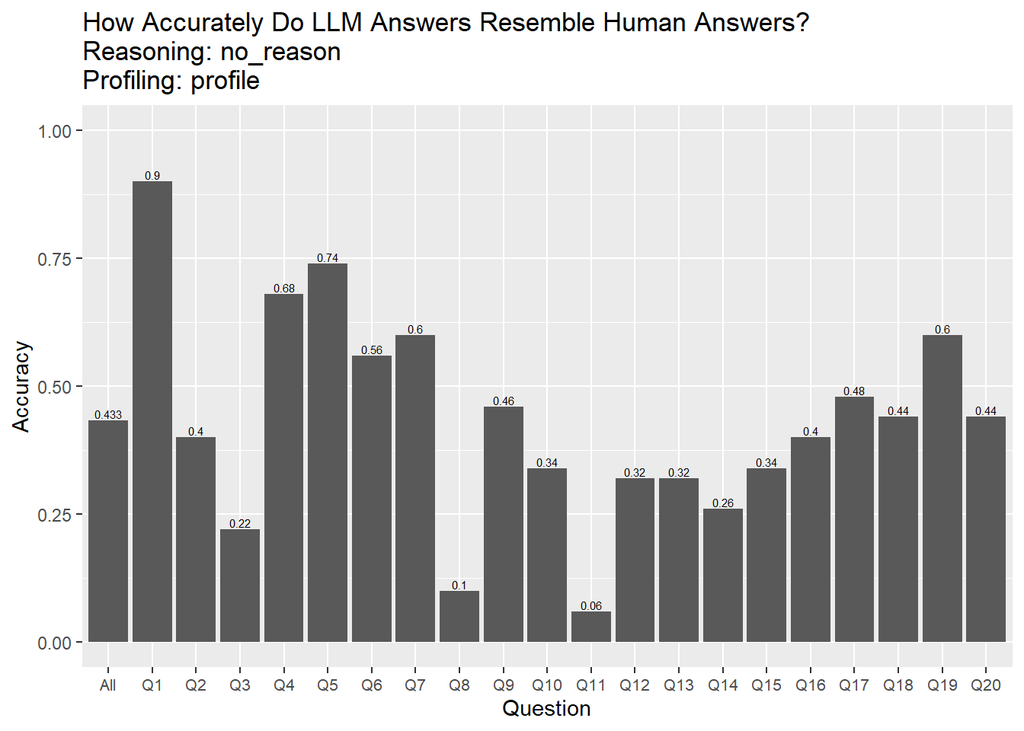

```r
reason <- paste(
  "Reasoning:",
  reasoning
)

profile <- paste(
  "Profiling:",
  profiling
)

title <- paste(
  "How Accurately Do LLM Answers Resemble Human Answers?",
  reason,
  profile,
  sep = "\n"
)
get_human_resemblance_plot(resemblance_dt, questions, title)
```

#### Accuracy

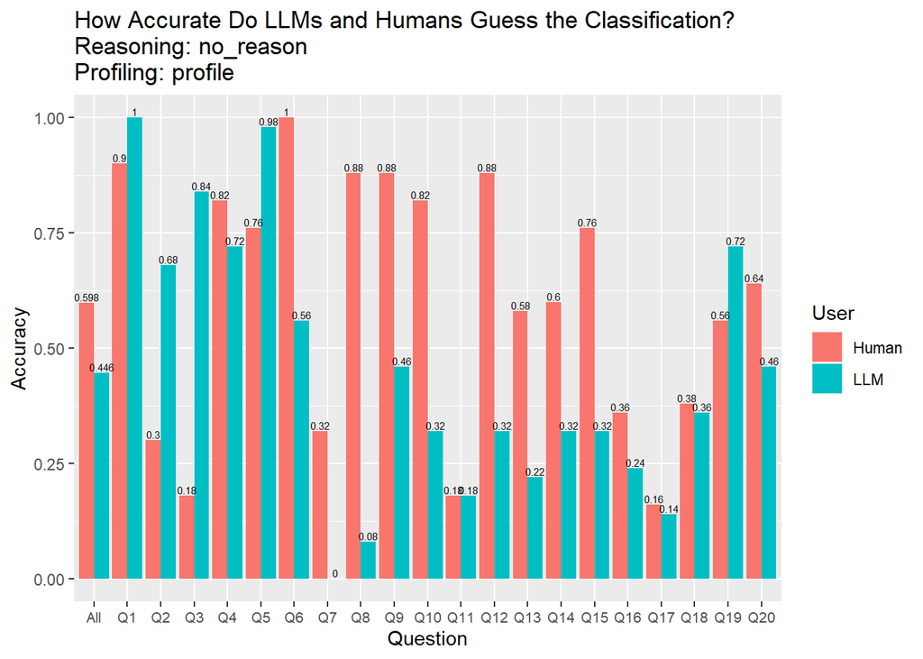

```
##     Human   LLM Question
##  1: 0.598 0.446      All
##  2: 0.900 1.000       Q1
##  3: 0.820 0.320      Q10
##  4: 0.180 0.180      Q11
##  5: 0.880 0.320      Q12
##  6: 0.580 0.220      Q13
##  7: 0.600 0.320      Q14
##  8: 0.760 0.320      Q15
##  9: 0.360 0.240      Q16
## 10: 0.160 0.140      Q17
## 11: 0.380 0.360      Q18
## 12: 0.560 0.720      Q19
## 13: 0.300 0.680       Q2
## 14: 0.640 0.460      Q20
## 15: 0.180 0.840       Q3
## 16: 0.820 0.720       Q4
## 17: 0.760 0.980       Q5
## 18: 1.000 0.560       Q6
## 19: 0.320 0.000       Q7
## 20: 0.880 0.080       Q8
## 21: 0.880 0.460       Q9
##     Human   LLM Question
```

```r
reason <- paste(
  "Reasoning:",
  reasoning
)

profile <- paste(
  "Profiling:",
  profiling
)

title <- paste(
  "How Accurate Do LLMs and Humans Guess the Classification?",
  reason,
  profile,
  sep = "\n"
)
get_accuracy_plot(accuracy_dt, questions, title)
```

#### Settings

```r
###############################################################################
# Change settings HERE
# Options: with, without
accuracy <- "without"
# Agreement questions to be visualized
questions <- paste0("A", c("2", "3", "5", "6"))
##############################################################################

path <- paste(
  "../gpt4-responses/v2_interview/out/agreement/",
  accuracy,
  "_accuracy_results.csv",
  sep = ''
)
```

#### Data Tables

```r
human_dt <- get_human_dt()
llm_dt <- get_llm_dt(path)
agreement_dt <- get_agreement_dt(questions, human_dt, llm_dt)
```

#### Human resemblance

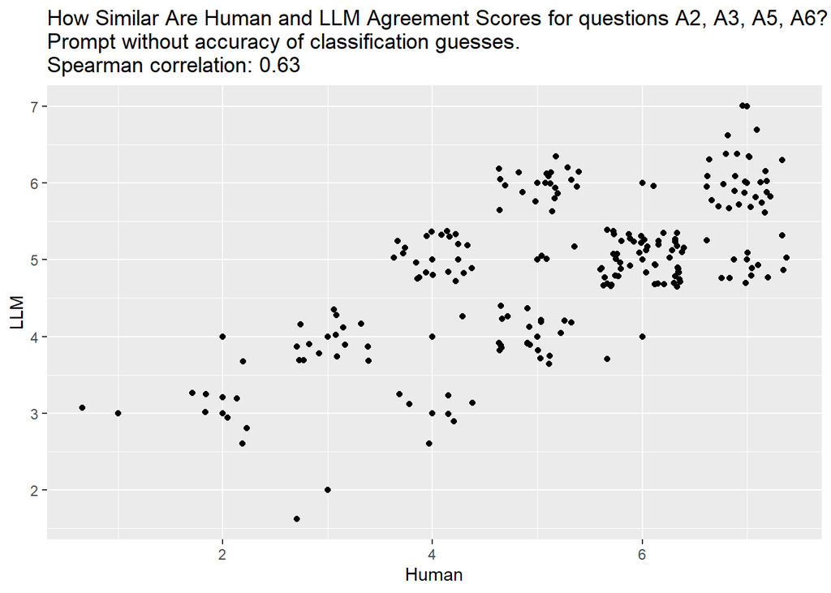

```r
agreement_questions <- paste(
  questions,
  collapse = ", "
)

prompting <- paste(
  "Prompt",
  accuracy,
  "accuracy of classification guesses."
)

correlation <- paste(
  "Spearman correlation:",
  as.character(
    round(cor(agreement_dt$Human, agreement_dt$LLM, method = "spearman"), 2)
  )
)

main <- paste(
  "How Similar Are Human and LLM Agreement Scores for questions ",
  agreement_questions,
  "?",
  sep = ""
)

title <- paste(
  main,
  prompting,
  correlation,
  sep = "\n"
)

get_agreement_plot(agreement_dt, title)
```

#### Statistical Tests

“The Spearman rank-order correlation coefficient (Spearman’s correlation, for short) is a nonparametric measure of the strength and direction of association that exists between two variables measured on at least an ordinal scale.” [Source](https://statistics.laerd.com/spss-tutorials/spearmans-rank-order-correlation-using-spss-statistics.php#:~:text=The%20Spearman%20rank%2Dorder%20correlation,letter%20%CF%81%2C%20pronounced%20rho).)

```r
cor.test(agreement_dt$Human, agreement_dt$LLM, method = "spearman")
```

```
##
##  Spearman's rank correlation rho
##
## data:  agreement_dt$Human and agreement_dt$LLM
## S = 492257, p-value < 2.2e-16
## alternative hypothesis: true rho is not equal to 0
## sample estimates:
##       rho
## 0.6307982
```

```r
wilcox.test(
  agreement_dt$Human,
  agreement_dt$LLM,
  paired = T,
  conf.int = T,
  alternative = "two.sided"
)
```

```
##
##  Wilcoxon signed rank test with continuity correction
##
## data:  agreement_dt$Human and agreement_dt$LLM
## V = 12318, p-value = 1.064e-05
## alternative hypothesis: true location shift is not equal to 0
## 95 percent confidence interval:
##  5.122653e-05 5.000371e-01
## sample estimates:
## (pseudo)median
##   9.787435e-06
```

```r
t.test(
  agreement_dt$Human,
  agreement_dt$LLM,
  paired = TRUE,
  alternative = "two.sided"
)
```

```
##
##  Paired t-test
##
## data:  agreement_dt$Human and agreement_dt$LLM
## t = 4.6059, df = 199, p-value = 7.321e-06
## alternative hypothesis: true mean difference is not equal to 0
## 95 percent confidence interval:
##  0.1944321 0.4855679
## sample estimates:
## mean difference
##            0.34
```